# **Correlational Analysis of MLB Team Payroll Spending and overall Team Success**

Noelle Fox and Julius Ejike-Charles

[noellefox.github.io](https://noellefox.github.io/)

# **Project background, logistics, and data**

**Motivation**: This project is our Final Project Portfolio for the Intro To Data Science Course (CMPS-3160) at Tulane University.

**Project Goal:** The aim of our project is to conduct a deeper analysis of MLB team payroll spending and how it correlates with overall team success. We will investigate whether higher spending is directly associated with better win–loss records, or if certain teams are achieving success despite smaller budgets. From there, we will analyze which player statistics teams appear to prioritize when allocating funds and evaluate whether these investments have translated into improved performance on the field.

**Collaboration Plan:** the remainder of the semester we will be meeting one to two evenings per week in the library for work sessions depending on our own personal schedules and the current demands of the project. We decided that in-person meetings would be the most effective to ensure work is evenly split and both of our opinions are being heard for a collaborative, well-rounded final. In between our weekly meetings we will be communicating through text messages.

We have set up a shared github repository to commit and track our code, ensuring we both can monitor progress, track history, and maintain version control. For the coding aspect of the project, we have additionally created a collaborative Colab notebook to jointly develop and test our analyses. This will allow for us both to efficiently build, refine, and update our work throughout the semester as we move through each milestone.

# Background and Supporting Sources

To make sure we fully understood the meaning behind each baseball statistic we analyzed, we looked at the MLB's official glossary, which breaks down all of the standard offensive metrics in a clear and consistent way. We also referenced articles discussing how teams, particularly smaller-market ones, are increasingly relying on analytics to stay competitive. These pieces helped shape the motivation for our project and reinforced why exploring the connection between payroll, performance, and efficiency matters in today's data-driven MLB landscape.

**Sources:**

- *MLB Glossary of Standard Statistics:* https://www.mlb.com/glossary/standard-stats
- *The Future of Analytics in Baseball (FanGraphs):* https://community.fangraphs.com/the-future-of-analytics-in-baseball-how-will-small-market-teams-fare/
- *Baseball Data Analytics Overview (Catapult):* https://www.catapult.com/blog/baseball-data-analytics

# Project Datasets

To explore the relationship between MLB payroll spending and team success, we are using multiple datasets that capture both team-level and player-level information. Together these datasets will allow us to analyze how much each team spends on its roster, how that spending translates to on-field performance, and which specific player statistics teams appear to prioritize when allocating their funds. By combining these data sources, we will be able to uncover patterns that link financial investments to player performance and overall team outcomes.

**Dataset 1:** Team payrolls and performance This dataset contains each MLB team’s total payroll for a given season (from 2011 to 2024) along with their corresponding win-loss record. We chose this dataset because it will serve as the foundation for our analysis in that it allows us to test our initial question ‘Do teams that spend more money actually perform better?’

*Question:* ‘Does higher team payroll correlate with greater success, as measured by total wins/losses in a season?’

*Statistics we can pull:* average team payroll per season, top-performing teams per dollar spent, correlation coefficient between payroll and win percentage.

*Link to data source:* https://www.kaggle.com/datasets/christophertreasure/mlb-team-payrolls-2011-2024

**Dataset 2:** Player Performance Statistics The dataset includes detailed player-level statistics such as batting average, on-base percentage, home runs, and other relevant performance metrics. It provides an understanding of how individual players contribute to team outcomes. We will use this dataset to explore what specific player characteristics or skills teams might be rewarding with higher salaries or greater investment. By linking this dataset with our third on player salaries, we can see what traits teams value more from a spending perspective.

*Question:* ‘Which player statistics appear to be most values by teams when determining payroll allocation?’

*Statistics we can pull:* top performing players, correlation between player wins and salary, and average performing metrics for top vs. bottom paid players.

*Link to data source:* https://baseballsavant.mlb.com/leaderboard/custom?year=2025%2C2024%2C2023%2C2022%2C2021%2C2020%2C2019%2C2018%2C2017%2C2016%2C2015%2C2014%2C2013%2C2012%2C2011&type=batter&filter=&min=150&selections=player_age%2Cab%2Cpa%2Chit%2Csingle%2Cdouble%2Ctriple%2Chome_run%2Cstrikeout%2Cwalk%2Ck_percent%2Cbb_percent%2Cbatting_avg%2Cslg_percent%2Con_base_percent%2Con_base_plus_slg%2Cb_rbi%2Cb_total_bases%2Cr_total_caught_stealing%2Cr_total_stolen_base%2Cb_gnd_into_dp%2Cb_hit_by_pitch%2Cb_hit_line_drive%2Cb_swinging_strike%2Cr_run%2Cwoba%2Cxwoba%2Cexit_velocity_avg%2Csweet_spot_percent%2Cbarrel_batted_rate%2Csolidcontact_percent%2Chard_hit_percent%2Cavg_best_speed%2Cavg_hyper_speed%2Cwhiff_percent%2Cswing_percent&chart=false&x=player_age&y=player_age&r=no&chartType=beeswarm&sort=player_name&sortDir=asc

**Dataset 3:** Player Team and Salary This dataset includes each player’s name, their team affiliation, and their corresponding yearly salary. This connects player-level earnings to both team payroll and individual performance. We are utilizing this because it will serve as the bridge between our payroll and performance datasets. This will allow us to explore how traits are being valued in terms of spending and if this is contributing to overall team success.

*Question:* ‘How do individual player salaries vary across teams, and do higher-paid players influence a team’s success?’

*Statistics we can pull:* average salary per team per position, salary distribution across the league, top highest players, and percentage of payroll contributed to the top earners of the team

*Link to data source:* https://www.kaggle.com/datasets/christophertreasure/mlb-player-salaries-2011-2024

**Together**: By using all three of these datasets we will be able to evaluate the relationship between financial investment and team success across multiple perspectives. The combined data will allow us to determine whether higher payrolls truly lead to stronger team performance and which specific player metrics drive salary and spending decisions. Furthermore we can uncover trends as to traits teams value the most, as reflected by their salary, and if these traits are contributing to team success.

# **ETL (Extract, Transform, & Load)**

**Mounting Google Drive**

```python
from google.colab import drive
drive.mount('/content/drive')
```

**Import Libraries** Below, we are importing some common libraries we will use to analyze our data in Google Colab. So far, we are using Pandas, NumPy, MatLab's Plotting Library, and Seaborn.

```python
#import libraries ----------------------------------------------------------------------------------------------------------
import pandas as pd
import numpy as np
import matplotlib.pyplot as plt
import seaborn as sns
```

# Team Payroll Dataset

**Importing Team Payrolls and Performance dataset**

Here we are importing the MLB payroll dataset and performing an initial cleanup for analysis. We drop unnecessary columns, clean the payroll values by removing symbols, and scale them into millions to make the data easier to interpret.

```python
#import dataset ----------------------------------------------------------------------------------------------------------
#URL for mlb team payrolls from 2011-2024
teamPayroll_URL = "https://raw.githubusercontent.com/noellefox/noellefox.github.io/refs/heads/main/datasets/mlb_payrolls.csv"
#read dataset from the
payroll = pd.read_csv(teamPayroll_URL)
```

```python
#clean the data ----------------------------------------------------------------------------------------------------

#only keep necessary columns
to_drop = ['Average Age', 'Active 26-Man', 'Injured', 'Retained', 'Buried', 'Postseason']   #columns to drop
payroll = payroll.drop(columns=to_drop, errors='ignore')      # drop the columns from the dataframe

#change payroll column from string to type float for efficient use later
payroll['Total Payroll Allocations'] = (
    payroll['Total Payroll Allocations']
      .astype(str)
      .str.replace(r'[\$,]', '', regex=True) #gets rid of dollar sign and
      .astype(float)
)

#change payroll column to be in millions to avoid scientific notation
payroll["Payroll_M"] = payroll["Total Payroll Allocations"] / 1_000_000
payroll.head()
```

|  | Team | Team Name | Year | Total Payroll Allocations | Wins | Losses | Payroll_M |
| --- | --- | --- | --- | --- | --- | --- | --- |
| 0 | OAK | Oakland Athletics | 2024 | 62132581.0 | 69 | 93 | 62.132581 |
| 1 | PIT | Pittsburgh Pirates | 2024 | 84050989.0 | 76 | 86 | 84.050989 |
| 2 | TB | Tampa Bay Rays | 2024 | 89707422.0 | 80 | 82 | 89.707422 |
| 3 | DET | Detroit Tigers | 2024 | 96961614.0 | 86 | 76 | 96.961614 |
| 4 | CLE | Cleveland Guardians | 2024 | 105224582.0 | 92 | 69 | 105.224582 |

# Player Statistics Dataset

**Importing Player Statistics dataset**

Here we are importing the player performance statistics dataset and performing initial cleaning steps. We remove unneeded columns and ensure that all performance metrics are converted into numeric types, allowing for accurate calculations and comparisons later on.

```python
#import dataset ----------------------------------------------------------------------------------------------------------

#URL for player performance statistics
stats_URL = "https://raw.githubusercontent.com/noellefox/noellefox.github.io/refs/heads/main/datasets/stats%20(2).csv"
#read dataset from the URL
stats = pd.read_csv(stats_URL)
```

```python
#clean the data ----------------------------------------------------------------------------------------------------

#drop unnecessary columns
to_drop = ['player_id', 'player_age'] #columns to drop
stats = stats.drop(columns = to_drop, errors = 'ignore')

#ensure numeric columns are the right type (floats)
numeric_cols = ['ab', 'pa', 'hit', 'single', 'double', 'triple', 'home_run',
    'strikeout', 'walk', 'k_percent', 'bb_percent', 'batting_avg', 'slg_percent',
    'on_base_percent', 'on_base_plus_slg', 'b_rbi', 'b_total_bases',
    'r_total_caught_stealing', 'r_total_stolen_base', 'b_gnd_into_dp',
    'b_hit_by_pitch', 'b_hit_line_drive', 'b_swinging_strike', 'r_run', 'woba',
    'xwoba', 'exit_velocity_avg', 'sweet_spot_percent', 'barrel_batted_rate',
    'solidcontact_percent', 'hard_hit_percent', 'whiff_percent', 'swing_percent'] #columns with numeric values we want to convert/ensure are float
stats[numeric_cols] = stats[numeric_cols].apply(pd.to_numeric, errors = 'coerce')
stats.head()
```

|  | last_name, first_name | year | ab | pa | hit | single | double | triple | home_run | strikeout | ... | xwoba | exit_velocity_avg | sweet_spot_percent | barrel_batted_rate | solidcontact_percent | hard_hit_percent | avg_best_speed | avg_hyper_speed | whiff_percent | swing_percent |
| --- | --- | --- | --- | --- | --- | --- | --- | --- | --- | --- | --- | --- | --- | --- | --- | --- | --- | --- | --- | --- | --- |
| 0 | Hunter, Torii | 2015 | 521 | 567 | 125 | 81 | 22 | 0 | 22 | 105 | ... | 0.290 | 88.5 | 28.5 | 5.0 | 5.2 | 34.9 | 98.563404 | 93.393480 | 23.1 | 53.4 |
| 1 | Ortiz, David | 2015 | 528 | 614 | 144 | 70 | 37 | 0 | 37 | 95 | ... | 0.420 | 93.0 | 34.8 | 13.1 | 8.4 | 49.1 | 102.851133 | 96.053058 | 23.2 | 44.7 |
| 2 | Rodriguez, Alex | 2015 | 523 | 620 | 131 | 75 | 22 | 1 | 33 | 145 | ... | 0.368 | 91.3 | 31.4 | 10.9 | 8.1 | 43.9 | 101.381141 | 95.014380 | 32.0 | 43.9 |
| 3 | Ramirez, Aramis | 2015 | 475 | 516 | 117 | 68 | 31 | 1 | 17 | 68 | ... | 0.304 | 87.4 | 33.5 | 5.6 | 6.6 | 34.5 | 97.851256 | 92.944763 | 17.9 | 52.9 |
| 4 | Beltré, Adrian | 2015 | 567 | 619 | 163 | 109 | 32 | 4 | 18 | 65 | ... | 0.360 | 89.5 | 35.7 | 5.5 | 7.8 | 40.4 | 99.252697 | 93.842412 | 16.8 | 48.1 |

5 rows × 37 columns

# Player Salary Dataset

**Import Player Salary dataset**

```python
#import dataset ----------------------------------------------------------------------------------------------------------

#URL for player performance statistics
salary_URL = "https://raw.githubusercontent.com/noellefox/noellefox.github.io/refs/heads/main/datasets/mlb_salary_data.csv"

#read dataset from the URL
salary = pd.read_csv(salary_URL, encoding = "latin1") #use latin1 encoding to avoid utf-8 error
```

```python
#clean the data ----------------------------------------------------------------------------------------------------

# Remove $ and commas, convert salary to float
salary['Salary'] = (
    salary['Salary']
        .astype(str)
        .str.replace(r'[\$,]', '', regex=True)
        .astype(float)
)

# Drop rows with missing salary values
salary = salary.dropna(subset=['Salary'])

salary.head()
```

|  | Year | Team | Name | Salary |
| --- | --- | --- | --- | --- |
| 0 | 2011 | ARI | Kelly Johnson | 5850000.0 |
| 1 | 2011 | ARI | Joe Saunders | 5500000.0 |
| 2 | 2011 | ARI | Chris Young | 5200000.0 |
| 3 | 2011 | ARI | Stephen Drew | 4650000.0 |
| 4 | 2011 | ARI | Justin Upton | 4458333.0 |

# Merging the Datasets

**Merging the Stats and Salary datasets**

Here we clean the three datasets further so that they can be merged consistently. We standardize column names, filter each dataset to only years in which they overlap, and normalize the player name formats. Finally, we merge the player salary and performance statistics into a single unified dataset that contains all relevent information for each player and season.

```python
#matching datasets to merge ----------------------------------------------------------------------------------------------------

#standardize column names across datasets
payroll = payroll.rename(columns={
    'Year': 'year',
    'Team': 'team code',
    'Team Name': 'team name',
    'Wins': 'wins',
    'Losses': 'losses'
})
stats = stats.rename(columns={
    'last_name, first_name': 'player name'
})
salary = salary.rename(columns={
    'Year': 'year',
    'Name': 'player name',
    'Team': 'team code',
    'Salary': 'salary'
})

#only keep years when the datasets overlap
valid_years = list(range(2015, 2024))
payroll = payroll[payroll['year'].isin(valid_years)]
stats = stats[stats['year'].isin(valid_years)]
salary = salary[salary['year'].isin(valid_years)]

#standardize player name format in player stats and player salary datasets
def clean_name(name):
    name = str(name).strip()
    if "," in name:
        last, first = name.split(",", 1)
        return f"{first.strip()} {last.strip()}"
    return name
stats['player name'] = stats['player name'].apply(clean_name)
salary['player name'] = salary['player name'].apply(clean_name)
```

```python
#merge stats+salary to have one dataset for player info ----------------------------------------------------------------------------------------------------
player_stats_salary = stats.merge(
    salary[["player name", "year", "team code", "salary"]],
    on=["player name", "year"],
    how="inner"
)
#reorder columns
first_cols = ["year", "player name", "team code", "salary"]
stat_cols = [c for c in player_stats_salary.columns if c not in first_cols]
player_stats_salary = player_stats_salary[first_cols + stat_cols]
player_stats_salary.head()
```

|  | year | player name | team code | salary | ab | pa | hit | single | double | triple | ... | xwoba | exit_velocity_avg | sweet_spot_percent | barrel_batted_rate | solidcontact_percent | hard_hit_percent | avg_best_speed | avg_hyper_speed | whiff_percent | swing_percent |
| --- | --- | --- | --- | --- | --- | --- | --- | --- | --- | --- | --- | --- | --- | --- | --- | --- | --- | --- | --- | --- | --- |
| 0 | 2015 | Torii Hunter | MIN | 10500000.0 | 521 | 567 | 125 | 81 | 22 | 0 | ... | 0.290 | 88.5 | 28.5 | 5.0 | 5.2 | 34.9 | 98.563404 | 93.393480 | 23.1 | 53.4 |
| 1 | 2015 | David Ortiz | BOS | 16000000.0 | 528 | 614 | 144 | 70 | 37 | 0 | ... | 0.420 | 93.0 | 34.8 | 13.1 | 8.4 | 49.1 | 102.851133 | 96.053058 | 23.2 | 44.7 |
| 2 | 2015 | Alex Rodriguez | NYY | 22000000.0 | 523 | 620 | 131 | 75 | 22 | 1 | ... | 0.368 | 91.3 | 31.4 | 10.9 | 8.1 | 43.9 | 101.381141 | 95.014380 | 32.0 | 43.9 |
| 3 | 2015 | Aramis Ramirez | MIL | 14000000.0 | 475 | 516 | 117 | 68 | 31 | 1 | ... | 0.304 | 87.4 | 33.5 | 5.6 | 6.6 | 34.5 | 97.851256 | 92.944763 | 17.9 | 52.9 |
| 4 | 2015 | Jayson Werth | WSH | 21000000.0 | 331 | 378 | 73 | 44 | 16 | 1 | ... | 0.331 | 90.0 | 35.2 | 7.9 | 8.7 | 40.7 | 100.894025 | 94.619068 | 24.2 | 37.9 |

5 rows × 39 columns

# **EDA (Exploratory Data Analysis)**

***Original Milestone One Foundational Analysis**

Here we have all of the additional columns we added to the payroll dataset to make analysis easier throughout the project. We create a column that calculates how many wins each team achieves for every million dollars they spend. We additionally add columns to rank important factors from highest to lowest such as payroll spending, number of wins, and the difference between the two.

```python
#compare teams on an equal footing by creating a cost-efficiency metric to see wins per million dollars
payroll['Wins per Million'] = payroll['wins'] / (payroll['Payroll_M'])

#compare teams within the same year
#positive values: outperform = more wins than payroll rank
#negative values: underperform = fewer wins than payroll rank
payroll['Payroll Rank'] = payroll.groupby('year')['Total Payroll Allocations'].rank(ascending=False) #rank by payroll
payroll['Wins Rank'] = payroll.groupby('year')['wins'].rank(ascending=False) #rank by wins
payroll['Rank Difference'] = payroll['Payroll Rank'] - payroll['Wins Rank'] #difference in rank to compare
payroll[['team code', 'year', 'Payroll Rank', 'Wins Rank', 'Rank Difference']].head()
```

|  | team code | year | Payroll Rank | Wins Rank | Rank Difference |
| --- | --- | --- | --- | --- | --- |
| 30 | BAL | 2023 | 29.0 | 2.0 | 27.0 |
| 31 | TB | 2023 | 27.0 | 4.0 | 23.0 |
| 32 | PIT | 2023 | 28.0 | 21.5 | 6.5 |
| 33 | CIN | 2023 | 24.0 | 16.0 | 8.0 |
| 34 | CLE | 2023 | 26.0 | 21.5 | 4.5 |

**Milestone Two Goal**: extract top 3 teams with the most wins per million spent and figure out what player stats are contributing the most to that

**Filtered Payroll**

**What this does:** Here we filter the payroll dataset to small and mid market MLB teams (ones that spend between 50-150 million) and create a scatterplot comparing payroll levels to total wins. Each color represents a different team, allowing us to compare performance across the league.

**Why:** We compute this to understand whether teams with moderate budgets are able to translate spending into wins. It helps identify which teams may be over or under performing relative to their payroll, which is essential to finding the most cost efficient teams

**Result**: The resulting visualization suggests that, within this spending range, higher payroll does not strongly guarantee more wins, teams with similar budgets can vary widely in performance.

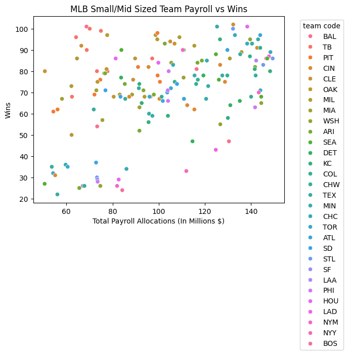

```python
#graph showing only teams that spend between 50-150 M

filtered_payroll = payroll[(payroll["Payroll_M"] >= 50) & (payroll["Payroll_M"] <= 150)]

sns.scatterplot(data = filtered_payroll, x = "Payroll_M", y = "wins", hue = "team code")
plt.title('MLB Small/Mid Sized Team Payroll vs Wins')
plt.xlabel('Total Payroll Allocations (In Millions $)')
plt.ylabel('Wins')
plt.legend(bbox_to_anchor=(1.05, 1), loc='upper left', title="team code")
plt.show()
```

**Top Performing Teams**

**What this does:** Here we calculate which teams get the best return on their payroll investment by computing wins per million for each team and averaging it across all seasons in the filtered range. Then, we sort the teams by this metric and extract the top three performers.

**Why:** We compute this to use for further analysis later on, to see what contributes to these specific teams success

**Result**: The results show that TB, CLE, and OAK consistently produce the most wins per million dollars spent.

```python
#teams ordered by wins per million to get top 3
team_rank = (
    filtered_payroll.groupby("team code")
    .agg({"Wins per Million": "mean"})
    .sort_values("Wins per Million", ascending=False))
top3_teams = list(team_rank.head(3).index)
top3_teams
```

```
['TB', 'CLE', 'OAK']
```

**League Average for Each Stat**

**What this does:** Here we calculate the weighted averages for every performance metric using at-bats (AB) as the weighting factor. This ensures that players with more opportunities at the plate contribute proportionally more to the overall average.

**Why**: We compute league wide averages so that we have a baseline to compare the top three cost efficient teams against. This allows us to see which stats these teams exceed the league in, helping us identify what skills they may be prioritizing when constructing their roster

**Result**: The resulting table provides a more accurate, adjusted view of league-wide performance.

```python
#weighted average weighted by AB for all teams
weighted_avgs = {}

for stat in stat_cols:
  weighted_avg = (player_stats_salary[stat] * player_stats_salary["ab"]).sum() / player_stats_salary["ab"].sum()
  weighted_avgs[stat] = weighted_avg

weighted_avgs_df = pd.DataFrame(weighted_avgs, index=["weighted_avg"]).T
weighted_avgs_df
```

|  | weighted_avg |
| --- | --- |
| ab | 428.225245 |
| pa | 479.363186 |
| hit | 111.660386 |
| single | 70.621116 |
| double | 22.449790 |
| triple | 2.132930 |
| home_run | 16.456549 |
| strikeout | 98.533556 |
| walk | 41.842582 |
| k_percent | 21.136541 |
| bb_percent | 8.606058 |
| batting_avg | 0.256483 |
| slg_percent | 0.429764 |
| on_base_percent | 0.326857 |
| on_base_plus_slg | 0.756621 |
| b_rbi | 57.766576 |
| b_total_bases | 187.745683 |
| r_total_caught_stealing | 2.448817 |
| r_total_stolen_base | 7.303616 |
| b_gnd_into_dp | 9.269060 |
| b_hit_by_pitch | 5.007883 |
| b_hit_line_drive | 53.626802 |
| b_swinging_strike | 178.976760 |
| r_run | 60.321924 |
| woba | 0.325152 |
| xwoba | 0.323413 |
| exit_velocity_avg | 88.674018 |
| sweet_spot_percent | 33.722355 |
| barrel_batted_rate | 7.455663 |
| solidcontact_percent | 6.046669 |
| hard_hit_percent | 37.332274 |
| avg_best_speed | 99.254127 |
| avg_hyper_speed | 93.824858 |
| whiff_percent | 24.009047 |
| swing_percent | 47.215208 |

**Team Averages for Each Stat**

**What this does**: Here we calculate the weighted average performance metrics for each team by grouping players by their team code and weighting each statistic by the number of at-bats. This method ensures that players with more playing time influence their team's average more heavily.

**Why**: We calculate the averages at the team level so we can summarize each teams profile across all its seasons and not just individual players. This allows us to compare how the top three teams are constructed relative to other teams when we look for the stats that may be leading to their success

**Result**: The resulting table summarizes each team's overall hitting profile across all seasons

```python
#average for each stat (weighted by ab) per team across years
def weighted_avgs_team (group):
  return pd.Series({
      stat: (group[stat] * group["ab"]).sum() / group["ab"].sum()
      for stat in stat_cols
  })

team_weighted_avgs = (
    player_stats_salary
    .groupby("team code")[stat_cols]
    .apply(weighted_avgs_team))

team_weighted_avgs.head()
```

| team code | ab | pa | hit | single | double | triple | home_run | strikeout | walk | k_percent | ... | xwoba | exit_velocity_avg | sweet_spot_percent | barrel_batted_rate | solidcontact_percent | hard_hit_percent | avg_best_speed | avg_hyper_speed | whiff_percent | swing_percent |
| --- | --- | --- | --- | --- | --- | --- | --- | --- | --- | --- | --- | --- | --- | --- | --- | --- | --- | --- | --- | --- | --- |
| ARI | 427.223356 | 479.588515 | 112.724971 | 70.053057 | 23.651125 | 3.521752 | 15.499037 | 97.897902 | 43.417212 | 20.916636 | ... | 0.318933 | 88.652924 | 33.101088 | 6.815239 | 6.119673 | 36.557280 | 99.053111 | 93.693953 | 23.614319 | 46.301818 |
| ATL | 449.216272 | 504.551971 | 120.673495 | 75.972588 | 24.286460 | 1.968466 | 18.445981 | 102.680690 | 46.055897 | 20.888062 | ... | 0.336030 | 89.159543 | 34.740896 | 8.450568 | 6.286399 | 38.858080 | 99.634653 | 94.085285 | 24.344625 | 48.635019 |
| BAL | 439.429410 | 483.243907 | 112.205708 | 70.694216 | 21.539872 | 1.360431 | 18.611188 | 109.556005 | 35.478091 | 23.118601 | ... | 0.316169 | 88.721120 | 33.815428 | 7.774596 | 6.331797 | 37.478381 | 99.562195 | 93.940152 | 26.289661 | 49.504454 |
| BOS | 461.319651 | 515.900488 | 127.596994 | 78.892610 | 28.792455 | 1.874632 | 18.037297 | 98.435963 | 45.960827 | 20.018287 | ... | 0.333053 | 89.322282 | 33.794017 | 8.032938 | 6.157733 | 39.129157 | 99.888387 | 94.193999 | 22.781558 | 46.529310 |
| CHC | 416.967518 | 474.737549 | 108.882823 | 66.988956 | 22.454228 | 2.414086 | 17.025552 | 101.247510 | 46.793958 | 21.721933 | ... | 0.329037 | 88.661553 | 33.627910 | 7.953741 | 5.770469 | 37.263772 | 99.405317 | 93.859766 | 25.139227 | 46.653251 |

5 rows × 35 columns

**Top Three Stats**

**What this does:** Here we compare the top three most payroll-efficient teams to the league-wide weighted averages for every statistic. By subtracting the league average from each team's AB-weighted performance, we measure how much better or worse these teams perform relative to the league. We then identify the top three statistics where these teams outperform the league the most.

**Why**: We compute this to identify which statistics the three most cost-efficient teams excel at the most. This reveals the key performance areas that may justify their payroll decisions.

```python
#extract top 3 stats for top 3 teams
top3_team_stats = team_weighted_avgs.loc[top3_teams] #get the weighted avg of stats for the top three teams

league_avg = weighted_avgs_df["weighted_avg"]
top3_diff = top3_team_stats.sub(league_avg, axis=1) #how much the top 3 teams differ from the league avg

mean_diff = top3_diff.mean(axis=0).sort_values(ascending=False) #the mean of the top 3 teams compared to league

top3_stats = mean_diff.head(3) #get the top 3 stats
top3_stats
```

|  | 0 |
| --- | --- |
| r_total_stolen_base | 0.870420 |
| double | 0.466950 |
| walk | 0.223362 |

**dtype:** float64

# **Model Questions**

*While our exploratory analysis identified stolen bases, doubles, and walks as the three statistics where the most cost-efficient teams most exceeded league averages, these metrics alone do not fully explain league-wide efficiency. To fully address our project goal we ask these model questions which aim to identify the performance statistics that best predict Wins per Million and total wins. Now we will broaden the analysis to include all hitting metrics across all MLB teams.*

1. What player statistics best predict a team's wins per million dollars spent?
- *Independent Variable*: Team level AB-weighted averages of hitting statistics
- *Dependent Variable:* Wins per Million dollars spent
- *Method*: a multiple linear regression model to estimate each stat's individual contribution so we can extract intepretable coefficiencts to explain which stats matter most
2. Can we predict a team's total wins based on payroll and performance metrics?
- *Independent Variable:* Payroll and Performance Stats
- *Dependent Variable:* Total wins
- *Method*: a multiple linear regression model to quantify how strongly each variable predicts wins and extract coefficients to show the direction and magnitude of each variables effect

# **Model One**

We built a multiple linear regression model using all AB-weighted hitting statistics to predict Wins per Million dollars spent. This allows us to see which offensive metrics have the strongest impact on cost-efficient team performance.

```python
# MODEL 1: Predict Wins per Million using ALL hitting stats

from sklearn.model_selection import train_test_split
from sklearn.linear_model import LinearRegression
from sklearn.metrics import r2_score, mean_squared_error

# Merge payroll with previously calculated team weighted stats
model1_df = payroll.merge(
    team_weighted_avgs.reset_index(),
    on='team code',
    how='inner'
)

# Dependent variable
y1 = model1_df['Wins per Million']

# Independent variables: ALL AB-weighted hitting stats
X1 = model1_df[stat_cols]     # stat_cols is the list of all hitting metrics

# Train-test split
X1_train, X1_test, y1_train, y1_test = train_test_split(
    X1, y1, test_size=0.2, random_state=42
)

# Fit model
model1 = LinearRegression()
model1.fit(X1_train, y1_train)

# Predictions
y1_pred = model1.predict(X1_test)

# Evaluation
print("Model 1 R^2:", r2_score(y1_test, y1_pred))
print("Model 1 RMSE:", np.sqrt(mean_squared_error(y1_test, y1_pred)))

# Coefficient table
coeff1 = pd.DataFrame({
    'Statistic': X1.columns,
    'Coefficient': model1.coef_
}).sort_values(by='Coefficient', ascending=False)
```

```
Model 1 R^2: 0.49188167788859005
Model 1 RMSE: 0.23793630418717773
```

**Results:** The model explains about 49% of the variation in Wins per Million, indicating a moderate ability to capture league-wide efficiency patterns. The RMSE suggests the model’s predictions are reasonably close to actual efficiency values.

This bar plot visualizes the regression coefficients, showing which hitting statistics have the strongest positive or negative influence on Wins per Million. It helps identify the offensive metrics most closely associated with team cost-efficiency.

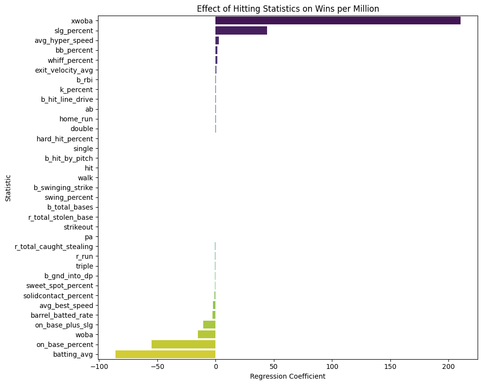

```python
plt.figure(figsize=(10,8))
sns.barplot(
    data=coeff1,
    x='Coefficient',
    y='Statistic',
    hue='Statistic',
    palette='viridis'
)
plt.title("Effect of Hitting Statistics on Wins per Million")
plt.xlabel("Regression Coefficient")
plt.ylabel("Statistic")
plt.tight_layout()
plt.show()
```

This graph compares the model's predicted Wins per Million to the actual values for each team. The closer the points fall to the red line, the more accurately the model captures how efficiently teams convert spending into wins.

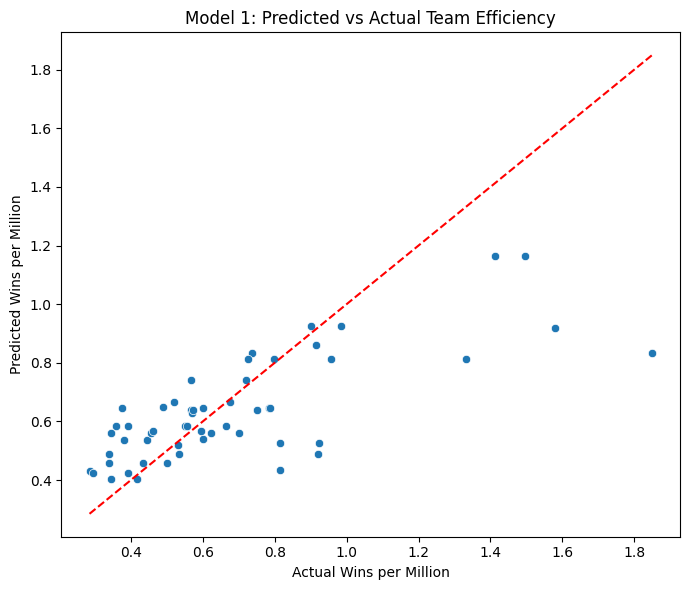

```python
plt.figure(figsize=(7,6))
sns.scatterplot(x=y1_test, y=y1_pred)
plt.plot([y1_test.min(), y1_test.max()], [y1_test.min(), y1_test.max()],
         color='red', linestyle='--')
plt.xlabel("Actual Wins per Million")
plt.ylabel("Predicted Wins per Million")
plt.title("Model 1: Predicted vs Actual Team Efficiency")
plt.tight_layout()
plt.show()
```

**Results:** The model generally captures the overall efficiency trend, but the scatter indicates variation around the ideal prediction line. This suggests that while hitting statistics help explain some differences in Wins per Million, other factors likely contribute to a team's true cost-efficiency as well.

# **Model Two**

After examining which offensive statistics drive cost-efficiency in Model 1, Model 2 shifts the focus to predicting a team's total wins using hitting performance **and** payroll. This model evaluates whether financial investment combined with offensive performance can explain overall success, and identifies which factors most strongly contribute to winning games.

```python
# MODEL 2: Predict Total Wins using Payroll + Hitting Stats

# Merge payroll with team weighted hitting stats
model2_df = payroll.merge(
    team_weighted_avgs.reset_index(),
    on='team code',
    how='inner'
)

# Dependent variable
y2 = model2_df['wins']

# Independent variables: payroll + all hitting stats
X2 = model2_df[['Payroll_M'] + stat_cols]

# Train-test split
X2_train, X2_test, y2_train, y2_test = train_test_split(
    X2, y2, test_size=0.2, random_state=42
)

# Fit model
model2 = LinearRegression()
model2.fit(X2_train, y2_train)

# Predictions
y2_pred = model2.predict(X2_test)

# Evaluation
print("Model 2 R²:", r2_score(y2_test, y2_pred))
print("Model 2 RMSE:", np.sqrt(mean_squared_error(y2_test, y2_pred)))

# Coefficient table
coeff2 = pd.DataFrame({
    'Feature': X2.columns,
    'Coefficient': model2.coef_
}).sort_values(by='Coefficient', ascending=False)
```

```
Model 2 R²: 0.3277669309454674
Model 2 RMSE: 17.429820137915545
```

**Results:** The model explains about 33% of the variation in total wins, indicating a modest ability to predict team success from payroll and hitting stats alone. The relatively high RMSE suggests that there are a number of other factors to consider when predicting wins.

This graph compares the model’s predicted win totals to the actual results for each team. The closer the points are to the red line, the more accurately the model captures how payroll and hitting performance translate into overall wins.

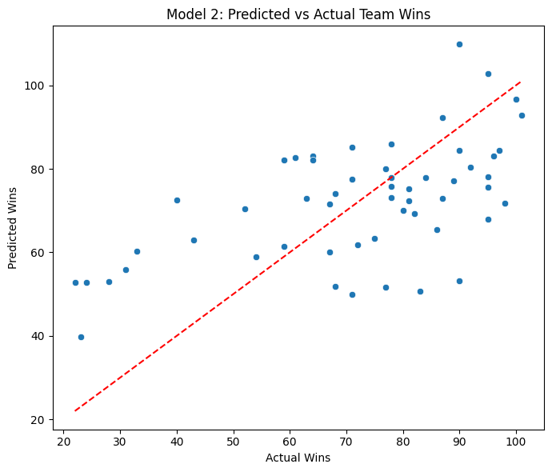

```python
plt.figure(figsize=(7,6))
sns.scatterplot(x=y2_test, y=y2_pred)
plt.plot([y2_test.min(), y2_test.max()], [y2_test.min(), y2_test.max()],
         color='red', linestyle='--')
plt.xlabel("Actual Wins")
plt.ylabel("Predicted Wins")
plt.title("Model 2: Predicted vs Actual Team Wins")
plt.tight_layout()
plt.show()
```

**Results:** The points show a general upward trend, meaning the model captures some of the relationship between payroll, hitting performance, and total wins. However, the wide spread around the red line indicates that many teams win more or fewer games than the model predicts, suggesting that factors outside payroll and hitting stats may play a role in determining overall success.

This graph shows how payroll and hitting statistics contribute to predicting a team’s total wins, unlike Model 1’s chart which focused only on cost-efficiency. By displaying each feature’s coefficient, it reveals which financial and performance factors most strongly drive overall team success.

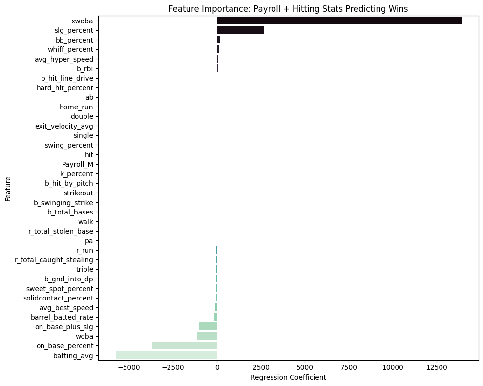

```python
plt.figure(figsize=(10,8))
sns.barplot(
    data=coeff2,
    x='Coefficient',
    y='Feature',
    hue='Feature',
    palette='mako'
)
plt.title("Feature Importance: Payroll + Hitting Stats Predicting Wins")
plt.xlabel("Regression Coefficient")
plt.ylabel("Feature")
plt.tight_layout()
plt.show()
```

# **Conclusion**

Our analysis uncovered that MLB team success is shaped not only by payroll size but also by how efficiently teams convert their financial resources into actual performance. Through EDA, we identified that small and mid-market teams can vary widely in their win totals despite similar spending, and that organizations like Tampa Bay (TB), Cleveland (CLE), and Oakland (OAK) consistently achieve the highest wins per million dollars spent. These teams outperform league-wide averages in key offensive areas—particularly stolen bases, doubles, and walks—suggesting that speed, extra-base hitting, and plate discipline help drive cost-effective success.

Our regression models reinforced and expanded these findings. Model 1 showed that hitting statistics can moderately predict a team's Wins per Million, explaining about half of the variation in efficiency. This indicates that a player's offensive skill does play a meaningful role in how well teams translate spending into performance, though it is not the sole contributor. Model 2, which incorporated both payroll and hitting metrics, captured a smaller share of the variation in total wins, emphasizing that while spending and offensive performance matter, team success also depends on factors beyond the scope of our datasets. Other factors may include pitching strength, defensive ability, injuries, and strategic management; these indicate a strong starting point for future research.

Together, these results highlight that high payrolls alone do not guarantee winning, and that strategic investment in the right kinds of offensive players can allow smaller-budget teams to compete at a high level. Ultimately, success in the MLB appears to arise from a combination of financial efficiency, roster construction, and underlying skill profiles, reinforcing the value of analytics in informing both spending decisions and long-term team strategy.

```python
%%shell
jupyter nbconvert --to html "/content/drive/MyDrive/Colab Notebooks/DataScienceFinalNotebook.ipynb"
```

```
[NbConvertApp] Converting notebook /content/drive/MyDrive/Colab Notebooks/DataScienceFinalNotebook.ipynb to html
[NbConvertApp] WARNING | Alternative text is missing on 5 image(s).
[NbConvertApp] Writing 847533 bytes to /content/drive/MyDrive/Colab Notebooks/DataScienceFinalNotebook.html
```